# Can a warm and supportive adult protect against mental health problems amongst adolescents exposed to adversity? A twin-differences study

Sarah E. Stock

This document was last edited on 2024-09-18 using R version 4.3.2

# 1 Preparation

Load the packages

```r
library(psych)    # for descriptives
library(polycor)  # for between pair correlations
library(geepack)  # for gee regressions
library(ggplot2)  # for graphs
library(dplyr)    # for grammar to allow %>%
library(ggeffects)# for gee graphs
library(emmeans)  # for gee graphs
library(ggpubr)   # for combining the ggplots together
library(stringr)  # for mutate function
library(data.table) # for set names function
library("Hmisc") # for within pair correlations
library(tidyr)
library(gtsummary)
options(scipen=999) #prevents scientific notation
```

Prepare variables (after bringing in data)

```r
erisk$behave5 <- NA; erisk$behave5 <- apply(erisk[,c("totagge5","totdele5")],1, sum, na.rm=F) # behavioural problems eldest twin (5)
erisk$behave12 <- NA; erisk$behave12 <- apply(erisk[,c("totagge12","totdele12")],1, sum, na.rm=F) # behavioural problems eldest (12)
erisk$behavy5 <- NA; erisk$behavy5 <- apply(erisk[,c("totaggy5","totdely5")],1, sum, na.rm=F) # behavioural problems youngest twin (5)
erisk$behavy12 <- NA; erisk$behavy12 <- apply(erisk[,c("totaggy12","totdely12")],1, sum, na.rm=F) # behavioural problems youngest twin (12)

erisk$matwarmthe <- NA; erisk$matwarmthe <- apply(erisk[,c("warme5","warme10")],1, mean, na.rm=T) # maternal warmth average eldest twin
erisk$matwarmthy <- NA; erisk$matwarmthy <- apply(erisk[,c("warmy5","warmy10")],1, mean, na.rm=T) # maternal warmth average youngest twin

erisk$aces1plus <- NA; erisk$aces1plus <- ifelse(erisk$acese512<1,0,1) # binary ACE variable (one or more ACE)
table(erisk$aces1plus)
```

# 2 Analysis

## 2.1 Descriptive statistics

### 2.1.1 Table 1. Descriptives statistics for mental health outcomes and protective factors according to ACE exposure.

```r
# No ACEs
erisk_0ace <- subset(erisk, aces1plus==0) # subset to just those with no ACEs
des_emo <- psych::describe(erisk_0ace$totemoe12)
des_beh <- psych::describe(erisk_0ace$behave12)
des_p <- psych::describe(erisk_0ace$PH_E)
des_mw <- psych::describe(erisk_0ace$matwarmthe)
des_ai <- psych::describe(erisk_0ace$adultec12)
## Print descriptives - No ACEs
des_emo # Emotional problems
des_beh # Behavioural problems
des_p # P-factor
des_mw # Maternal warmth
des_ai # Adult support

# One or more ACEs
erisk_1ace <- subset(erisk, aces1plus==1)
des_emo <- psych::describe(erisk_1ace$totemoe12)
des_beh <- psych::describe(erisk_1ace$behave12)
des_p <- psych::describe(erisk_1ace$PH_E)
des_mw <- psych::describe(erisk_1ace$matwarmthe)
des_ai <- psych::describe(erisk_1ace$adultec12)
## Print descriptives - One or more ACEs
des_emo # Emotional problems
des_beh # Behavioural problems
des_p # P-factor
des_mw # Maternal warmth
des_ai # Adult support
```

## 2.2 Preliminary analysis

Running GEE models to test association between experiencing one or more ACE and mental health outcomes

```r
# Emotional problems at age 12
erisk_subset <- subset(erisk,!is.na(totemoe12) & !is.na(aces1plus))
oneace_emo <- geeglm(scale(totemoe12)~aces1plus, data=erisk_subset, id=familyid, corstr="exchangeable")
tidy(oneace_emo, conf.int = TRUE, conf.level = 0.95)
# Behavioural problems at age 12
erisk_subset <- subset(erisk,!is.na(behave12) & !is.na(aces1plus))
oneace_beh <- geeglm(scale(behave12)~aces1plus, data=erisk_subset, id=familyid, corstr="exchangeable")
tidy(oneace_beh, conf.int = TRUE, conf.level = 0.95)
# P-Factor at age 18
erisk_subset <- subset(erisk,!is.na(PH_E) & !is.na(aces1plus))
oneace_p <- geeglm(scale(PH_E)~aces1plus, data=erisk_subset, id=familyid, corstr="exchangeable")
tidy(oneace_p, conf.int = TRUE, conf.level = 0.95)

# Check concordance of ACEs within twin pairs
test <- subset(erisk, rorderp5==0)
hetcor(test$acese512, test$acesy512)
```

Standardise all the outcome and exposure variables, for use in analysis.

```r
# Standardise outcomes
erisk_1ace$totemoe12sd <- scale(erisk_1ace$totemoe12)
erisk_1ace$totemoy12sd <- scale(erisk_1ace$totemoy12)
erisk_1ace$behave12sd <- scale(erisk_1ace$behave12)
erisk_1ace$behavy12sd <- scale(erisk_1ace$behavy12)
erisk_1ace$PH_Esd <- scale(erisk_1ace$PH_E)
erisk_1ace$PH_Ysd <- scale(erisk_1ace$PH_Y)
# Standardise exposures
erisk_1ace$matwarmthesd <- scale(erisk_1ace$matwarmthe)
erisk_1ace$matwarmthysd <- scale(erisk_1ace$matwarmthy)
erisk_1ace$adultec12sd <- scale(erisk_1ace$adultec12)
erisk_1ace$adultyc12sd <- scale(erisk_1ace$adultyc12)
# Standardise covariates
erisk_1ace$totemoe5sd <- scale(erisk_1ace$totemoe5)
erisk_1ace$totemoy5sd <- scale(erisk_1ace$totemoy5)
erisk_1ace$behave5sd <- scale(erisk_1ace$behave5)
erisk_1ace$behavy5sd <- scale(erisk_1ace$behavy5)
```

## 2.3 Main analysis

Phenotypic analysis

```r
# Maternal warmth & emotional problems
test <- subset(erisk_1ace, !is.na(totemoe12sd) & !is.na(matwarmthesd))
geemodel <- geeglm(scale(totemoe12sd)~scale(matwarmthesd), data=test, id=familyid, corstr="exchangeable")
mw_emo <- tidy(geemodel, conf.int = TRUE, conf.level = 0.95) [2, c(2,6,7)]; mw_emo <- as.data.frame(mw_emo)
# Maternal warmth & behavioural problems
test <- subset(erisk_1ace, !is.na(behave12sd) & !is.na(matwarmthesd))
geemodel <- geeglm(scale(behave12sd)~scale(matwarmthesd), data=test, id=familyid, corstr="exchangeable")
mw_beh <- tidy(geemodel, conf.int = TRUE, conf.level = 0.95) [2, c(2,6,7)]; mw_beh <- as.data.frame(mw_beh) #
# Maternal warmth & p-factor
test <- subset(erisk_1ace, !is.na(PH_Esd) & !is.na(matwarmthesd))
geemodel <- geeglm(scale(PH_Esd)~scale(matwarmthesd), data=test, id=familyid, corstr="exchangeable")
mw_p <- tidy(geemodel, conf.int = TRUE, conf.level = 0.95) [2, c(2,6,7)]; mw_p <- as.data.frame(mw_p)
# Adult support & emotional problems
test <- subset(erisk_1ace, !is.na(totemoe12sd) & !is.na(adultec12sd))
geemodel <- geeglm(scale(totemoe12sd)~scale(adultec12sd), data=test, id=familyid, corstr="exchangeable")
ai_emo <- tidy(geemodel, conf.int = TRUE, conf.level = 0.95) [2, c(2,6,7)]; ai_emo <- as.data.frame(ai_emo)
# Adult support & behavioural problems
test <- subset(erisk_1ace,  !is.na(behave12sd) & !is.na(adultec12sd))
geemodel <- geeglm(scale(behave12sd)~scale(adultec12sd), data=test, id=familyid, corstr="exchangeable")
ai_beh <- tidy(geemodel, conf.int = TRUE, conf.level = 0.95) [2, c(2,6,7)]; ai_beh <- as.data.frame(ai_beh)
# Adult support & p-factor
test <- subset(erisk_1ace, !is.na(PH_Esd) & !is.na(adultec12sd))
geemodel <- geeglm(scale(PH_Esd)~scale(adultec12sd), data=test, id=familyid, corstr="exchangeable")
ai_p <- tidy(geemodel, conf.int = TRUE, conf.level = 0.95) [2, c(2,6,7)]; ai_p <- as.data.frame(ai_p)

rq1unadjusted <- rbind(mw_emo, mw_beh, mw_p, ai_emo, ai_beh, ai_p)
rq1unadjusted$model <- NA; rq1unadjusted$model <- 1
rq1unadjusted$pf <- NA; rq1unadjusted$pf <- c("MW", "MW", "MW", "AI", "AI", "AI")
rq1unadjusted$outcome <- NA; rq1unadjusted$outcome <- c("Emotional","Behavioural", "P-Factor")
rq1unadjusted <- rq1unadjusted [,c(4,5,6,1,2,3)]
model1 <- rq1unadjusted # save before changing names to allow to combine in tables
rq1unadjusted <- rq1unadjusted %>%
   rename(
      est_1 = estimate,
      lowci_1 = conf.low,
      highci_1 = conf.high
   )
```

MZ & DZ twin analysis

```r
# Calculate mean and twin difference scores based off standardised measures
erisk_1ace$matwarm_mean <- NA; erisk_1ace$matwarm_mean <- rowMeans(erisk_1ace[,c("matwarmthesd", "matwarmthysd")])
erisk_1ace$adult_mean <- NA; erisk_1ace$adult_mean <- rowMeans(erisk_1ace[,c("adultec12sd", "adultyc12sd")])
erisk_1ace$emo5_mean <- NA; erisk_1ace$emo5_mean <- rowMeans(erisk_1ace[,c("totemoe5sd", "totemoy5sd")])
erisk_1ace$beh5_mean <- NA; erisk_1ace$beh5_mean <- rowMeans(erisk_1ace[,c("behave5sd", "behavy5sd")])
erisk_1ace$matwarm_diff1 <- NA; erisk_1ace$matwarm_diff1 <- erisk_1ace$matwarmthesd - erisk_1ace$matwarm_mean
erisk_1ace$adult_diff1 <- NA; erisk_1ace$adult_diff1 <- erisk_1ace$adultec12sd - erisk_1ace$adult_mean
erisk_1ace$emo5_diff1 <- NA; erisk_1ace$emo5_diff1 <- erisk_1ace$totemoe5sd - erisk_1ace$emo5_mean
erisk_1ace$beh5_diff1 <- NA; erisk_1ace$beh5_diff1 <- erisk_1ace$behave5sd - erisk_1ace$beh5_mean

# Run analysis
# Maternal warmth & emotional problems
test <- subset(erisk_1ace, !is.na(totemoe12sd) & !is.na(matwarm_mean))
geemodel <- geeglm(scale(totemoe12sd) ~ scale(matwarm_mean) + scale(matwarm_diff1), data=test,
                   id=familyid, corstr="exchangeable")
mw_emo <- tidy(geemodel, conf.int = TRUE, conf.level = 0.95) [c(3),c(2,6,7)]; mw_emo <- as.data.frame(mw_emo)
# Maternal warmth & behavioural problems
test <- subset(erisk_1ace, !is.na(behave12sd) & !is.na(matwarm_mean))
geemodel <- geeglm(scale(behave12sd) ~ scale(matwarm_mean) + scale(matwarm_diff1), data=test,
                   id=familyid, corstr="exchangeable")
mw_beh <- tidy(geemodel, conf.int = TRUE, conf.level = 0.95) [c(3),c(2,6,7)]; mw_beh <- as.data.frame(mw_beh)
# Maternal warmth & p-factor
test <- subset(erisk_1ace, !is.na(PH_Esd) & !is.na(matwarm_mean))
geemodel <- geeglm(scale(PH_Esd) ~ scale(matwarm_mean) + scale(matwarm_diff1), data=test,
                   id=familyid, corstr="exchangeable")
mw_p <- tidy(geemodel, conf.int = TRUE, conf.level = 0.95) [c(3),c(2,6,7)]; mw_p <- as.data.frame(mw_p)
# Adult support & emotional problems
test <- subset(erisk_1ace, !is.na(totemoe12sd) & !is.na(adult_mean))
geemodel <- geeglm(scale(totemoe12sd) ~ scale(adult_mean) + scale(adult_diff1), data=test,
                   id=familyid, corstr="exchangeable")
ai_emo <- tidy(geemodel, conf.int = TRUE, conf.level = 0.95) [c(3),c(2,6,7)]; ai_emo <- as.data.frame(ai_emo)
# Adult support & behavioural problems
test <- subset(erisk_1ace, !is.na(behave12sd) & !is.na(adult_mean))
geemodel <- geeglm(scale(behave12sd) ~ scale(adult_mean) + scale(adult_diff1), data=test,
                   id=familyid, corstr="exchangeable")
ai_beh <- tidy(geemodel, conf.int = TRUE, conf.level = 0.95) [c(3),c(2,6,7)]; ai_beh <- as.data.frame(ai_beh)
# Adult support & p-factor
test <- subset(erisk_1ace, !is.na(PH_Esd) & !is.na(adult_mean))
geemodel <- geeglm(scale(PH_Esd) ~ scale(adult_mean) + scale(adult_diff1), data=test,
                   id=familyid, corstr="exchangeable")
ai_p <- tidy(geemodel, conf.int = TRUE, conf.level = 0.95) [c(3),c(2,6,7)]; ai_p <- as.data.frame(ai_p)

# save results to data frame
rq2unadjustedalltwin <- rbind(mw_emo, mw_beh, mw_p, ai_emo, ai_beh, ai_p)
rq2unadjustedalltwin$model <- NA; rq2unadjustedalltwin$model <- 2
rq2unadjustedalltwin$pf <- NA; rq2unadjustedalltwin$pf <- c("MW", "MW", "MW", "AI", "AI", "AI")
rq2unadjustedalltwin$outcome <- NA; rq2unadjustedalltwin$outcome <- c("Emotional","Behavioural", "P-Factor")
rq2unadjustedalltwin <- rq2unadjustedalltwin [,c(4,5,6,1,2,3)]
model2 <- rq2unadjustedalltwin
rq2unadjustedalltwin <-  rq2unadjustedalltwin %>%
   rename(
      est_2 = estimate,
      lowci_2 = conf.low,
      highci_2 = conf.high
   )
```

MZ twin analysis

```r
# Maternal warmth & emotional problems
test <- subset(erisk_1ace, zygosity==1 & !is.na(totemoe12sd) & !is.na(matwarm_mean))
geemodel <- geeglm(scale(totemoe12sd) ~ scale(matwarm_mean) + scale(matwarm_diff1), data=test,
                   id=familyid, corstr="exchangeable")
mw_emo <- tidy(geemodel, conf.int = TRUE, conf.level = 0.95) [c(3),c(2,6,7)]; mw_emo <- as.data.frame(mw_emo)
# Maternal warmth & behavioural problems
test <- subset(erisk_1ace, zygosity==1 & !is.na(behave12sd) & !is.na(matwarm_mean))
geemodel <- geeglm(scale(behave12sd) ~ scale(matwarm_mean) + scale(matwarm_diff1), data=test,
                   id=familyid, corstr="exchangeable")
mw_beh <- tidy(geemodel, conf.int = TRUE, conf.level = 0.95) [c(3),c(2,6,7)]; mw_beh <- as.data.frame(mw_beh)
# Maternal warmth & p-factor
test <- subset(erisk_1ace, zygosity==1 & !is.na(PH_E) & !is.na(matwarm_mean))
geemodel <- geeglm(scale(PH_Esd) ~ scale(matwarm_mean) + scale(matwarm_diff1), data=test,
                   id=familyid, corstr="exchangeable")
mw_p <- tidy(geemodel, conf.int = TRUE, conf.level = 0.95) [c(3),c(2,6,7)]; mw_p <- as.data.frame(mw_p)
# Adult support & emotional problems
test <- subset(erisk_1ace, zygosity==1 & !is.na(totemoe12sd) & !is.na(adult_mean))
geemodel <- geeglm(scale(totemoe12sd) ~ scale(adult_mean) + scale(adult_diff1), data=test,
                   id=familyid, corstr="exchangeable")
ai_emo <- tidy(geemodel, conf.int = TRUE, conf.level = 0.95) [c(3),c(2,6,7)]; ai_emo <- as.data.frame(ai_emo)
# Adult support & behavioural problems
test <- subset(erisk_1ace, zygosity==1 & !is.na(behave12sd) & !is.na(adult_mean))
geemodel <- geeglm(scale(behave12sd) ~ scale(adult_mean) + scale(adult_diff1), data=test,
                   id=familyid, corstr="exchangeable")
ai_beh <- tidy(geemodel, conf.int = TRUE, conf.level = 0.95) [c(3),c(2,6,7)]; ai_beh <- as.data.frame(ai_beh)
# Adult support & p-factor
test <- subset(erisk_1ace, zygosity==1 & !is.na(PH_Esd) & !is.na(adult_mean))
geemodel <- geeglm(scale(PH_Esd) ~ scale(adult_mean) + scale(adult_diff1), data=test,
                   id=familyid, corstr="exchangeable")
ai_p <- tidy(geemodel, conf.int = TRUE, conf.level = 0.95) [c(3),c(2,6,7)]; ai_p <- as.data.frame(ai_p)

# save results to data frame
rq2unadjustedmz <- rbind(mw_emo, mw_beh, mw_p, ai_emo, ai_beh, ai_p)
rq2unadjustedmz$model <- NA; rq2unadjustedmz$model <- 3
rq2unadjustedmz$pf <- NA; rq2unadjustedmz$pf <- c("MW", "MW", "MW", "AI", "AI", "AI")
rq2unadjustedmz$outcome <- NA; rq2unadjustedmz$outcome <- c("Emotional","Behavioural", "P-Factor")
rq2unadjustedmz <- rq2unadjustedmz [,c(4,5,6,1,2,3)]
model3 <- rq2unadjustedmz
rq2unadjustedmz <-  rq2unadjustedmz %>%
   rename(
      est_3 = estimate,
      lowci_3 = conf.low,
      highci_3 = conf.high
   )
```

MZ twin analysis - adjusted

```r
# Maternal warmth & emotional problems
test <- subset(erisk_1ace, zygosity==1 & !is.na(totemoe12sd) & !is.na(matwarm_mean))
geemodel <- geeglm(scale(totemoe12sd) ~ scale(matwarm_mean) + scale(matwarm_diff1) + emo5_mean + emo5_diff1,
                   data=test, id=familyid, corstr="exchangeable")
mw_emo <- tidy(geemodel, conf.int = TRUE, conf.level = 0.95) [c(3),c(2,6,7)]; mw_emo <- as.data.frame(mw_emo)
# Maternal warmth & behavioural problems
test <- subset(erisk_1ace, zygosity==1 & !is.na(behave12sd) & !is.na(matwarm_mean))
geemodel <- geeglm(scale(behave12sd) ~ scale(matwarm_mean) + scale(matwarm_diff1) + beh5_mean + beh5_diff1,
                   data=test, id=familyid, corstr="exchangeable")
mw_beh <- tidy(geemodel, conf.int = TRUE, conf.level = 0.95) [c(3),c(2,6,7)]; mw_beh <- as.data.frame(mw_beh)
# Maternal warmth & p-factor
test <- subset(erisk_1ace, zygosity==1 & !is.na(PH_Esd) & !is.na(matwarm_mean))
geemodel <- geeglm(scale(PH_Esd) ~ scale(matwarm_mean) + scale(matwarm_diff1) + emo5_mean + emo5_diff1 + beh5_mean + beh5_diff1,
                   data=test, id=familyid, corstr="exchangeable")
mw_p <- tidy(geemodel, conf.int = TRUE, conf.level = 0.95) [c(3),c(2,6,7)]; mw_p <- as.data.frame(mw_p)
# Adult support & emotional problems
test <- subset(erisk_1ace, zygosity==1 & !is.na(totemoe12sd) & !is.na(adult_mean))
geemodel <- geeglm(scale(totemoe12sd) ~ scale(adult_mean) + scale(adult_diff1) + emo5_mean + emo5_diff1,
                   data=test, id=familyid, corstr="exchangeable")
ai_emo <- tidy(geemodel, conf.int = TRUE, conf.level = 0.95) [c(3),c(2,6,7)]; ai_emo <- as.data.frame(ai_emo)
# Adult support & behavioural problems
test <- subset(erisk_1ace, zygosity==1 & !is.na(behave12sd) & !is.na(adult_mean))
geemodel <- geeglm(scale(behave12sd) ~ scale(adult_mean) + scale(adult_diff1) + beh5_mean + beh5_diff1,
                   data=test, id=familyid, corstr="exchangeable")
ai_beh <- tidy(geemodel, conf.int = TRUE, conf.level = 0.95) [c(3),c(2,6,7)]; ai_beh <- as.data.frame(ai_beh)
# Adult support & p-factor
test <- subset(erisk_1ace, zygosity==1 & !is.na(PH_Esd) & !is.na(adult_mean))
geemodel <- geeglm(scale(PH_Esd) ~ scale(adult_mean) + scale(adult_diff1) + emo5_mean + emo5_diff1 + beh5_mean + beh5_diff1,
                   data=test, id=familyid, corstr="exchangeable")
ai_p <- tidy(geemodel, conf.int = TRUE, conf.level = 0.95) [c(3),c(2,6,7)]; ai_p <- as.data.frame(ai_p)

# save results to data frame
rq2adjustedmz <- rbind(mw_emo, mw_beh, mw_p, ai_emo, ai_beh, ai_p)
rq2adjustedmz$model <- NA; rq2adjustedmz$model <- 4
rq2adjustedmz$pf <- NA; rq2adjustedmz$pf <- c("MW", "MW", "MW", "AI", "AI", "AI")
rq2adjustedmz$outcome <- NA; rq2adjustedmz$outcome <- c("Emotional","Behavioural", "P-Factor");
rq2adjustedmz <- rq2adjustedmz [,c(4,5,6,1,2,3)]
model4 <- rq2adjustedmz
rq2adjustedmz <- rq2adjustedmz %>%
   rename(
      est_4 = estimate,
      lowci_4 = conf.low,
      highci_4 = conf.high
   )
```

### 2.3.1 Table 2. Associations between warm and supportive adult involvement and mental health problems, amongst children exposed to ACEs

Model 1 - Phenotypic analysis. Model 2 - MZ & DZ twin analysis. Model 3 - MZ twin analysis. Model 4 - MZ twin analysis adjusted.

```r
allmodels <- rbind( model1, model2, model3, model4)
allmodels
```

Create a wide and long format dataframe

```r
# Select the data from each model
mw_emo <- as.data.frame(c(rq1unadjusted[1,],rq2unadjustedalltwin[1,],rq2unadjustedmz[1,],rq2adjustedmz[1,]))
mw_beh <- as.data.frame(c(rq1unadjusted[2,],rq2unadjustedalltwin[2,],rq2unadjustedmz[2,],rq2adjustedmz[2,]))
mw_p <- as.data.frame(c(rq1unadjusted[3,],rq2unadjustedalltwin[3,],rq2unadjustedmz[3,],rq2adjustedmz[3,]))
ai_emo <- as.data.frame(c(rq1unadjusted[4,],rq2unadjustedalltwin[4,],rq2unadjustedmz[4,],rq2adjustedmz[4,]))
ai_beh <- as.data.frame(c(rq1unadjusted[5,],rq2unadjustedalltwin[5,],rq2unadjustedmz[5,],rq2adjustedmz[5,]))
ai_p <- as.data.frame(c(rq1unadjusted[6,],rq2unadjustedalltwin[6,],rq2unadjustedmz[6,],rq2adjustedmz[6,]))
# Create wide dataframe
overall_table_wide <- rbind(mw_emo, mw_beh, mw_p, ai_emo, ai_beh, ai_p)
overall_table_wide <- select(overall_table_wide, -c(pf.1, outcome.1, pf.2, outcome.2, pf.3, outcome.3))
# Reshape into a long dataframe
overall_table_long <- reshape(overall_table_wide,
                              varying = c("est_1", "highci_1", "lowci_1",
                                          "est_2",  "highci_2", "lowci_2",
                                          "est_3",  "highci_3", "lowci_3",
                                          "est_4",  "highci_4", "lowci_4"),
                              v.names = c("est", "lowci", "highci"),
                              direction = "long", idvar= c("pf", "outcome"),
                              timevar = "type", sep=" ")
overall_table_long <- select(overall_table_long, -c(model, model.1, model.2, model.3))

# Re-label 'type' variable indicating whether is phenotypic, dz, mz, or mz_adjusted
overall_table_long$type <-factor(overall_table_long$type, levels=c("1","2","3","4"), labels=c("pheno", "mz_dz", "mz", "mz_adj"))
# Order variables by analysis type for plot (back to front order)
overall_table_long$type <- ordered(overall_table_long$type, c("mz_adj", "mz", "mz_dz", "pheno"))
```

Estimate reduction in effect size from phenotypic to DZ & MZ (all twin = at) estimates & from phenotypic to MZ estimates. Note: Proportional decrease = (Original Number - New Number)/Original Number

```r
# Rename variables
setnames(model1, old = c("model", "pf", "outcome", "estimate", "conf.low", "conf.high"), new = c("model", "pf", "outcome", "estimate_ph", "conf.low_ph", "conf.high_ph"), skip_absent = T)
setnames(model2, old = c("model", "pf", "outcome", "estimate", "conf.low", "conf.high"), new = c("model", "pf", "outcome", "estimate_at", "conf.low_at", "conf.high_at"), skip_absent = T)
setnames(model3, old = c("model", "pf", "outcome", "estimate", "conf.low", "conf.high"), new = c("model", "pf", "outcome", "estimate_mz", "conf.low_mz", "conf.high_mz"), skip_absent = T)

model1_mw <- model1[c(1,2,3),]
model1_ai <- model1[c(4,5,6),]
model2_mw <- model2[c(1,2,3),]
model2_ai <- model2[c(4,5,6),]
model3_mw <- model3[c(1,2,3),]
model3_ai <- model3[c(4,5,6),]

# all twin comparison table - Maternal warmth
comparison_table_mw_at <- merge(model1_mw, model2_mw, by="outcome")
comparison_table_ai_at <- merge(model1_ai, model2_ai, by="outcome")
# mz comparison table
comparison_table_mw_mz <- merge(model1_mw, model3_mw, by="outcome")
comparison_table_ai_mz <- merge(model1_ai, model3_ai, by="outcome")

# Derive variable indexing reduction in effects from phenotypic to MZ analysis
# all twin
comparison_table_mw_at$percent_decrease_at <- (comparison_table_mw_at$estimate_ph - comparison_table_mw_at$estimate_at) / comparison_table_mw_at$estimate_ph
comparison_table_ai_at$percent_decrease_at <- (comparison_table_ai_at$estimate_ph - comparison_table_ai_at$estimate_at) / comparison_table_ai_at$estimate_ph
# mz twin
comparison_table_mw_mz$percent_decrease_mz <- (comparison_table_mw_mz$estimate_ph - comparison_table_mw_mz$estimate_mz) / comparison_table_mw_mz$estimate_ph
comparison_table_ai_mz$percent_decrease_mz <- (comparison_table_ai_mz$estimate_ph - comparison_table_ai_mz$estimate_mz) / comparison_table_ai_mz$estimate_ph

# Average percentage decrease
# AT analysis - Maternal warmth
mean(comparison_table_mw_at$percent_decrease_at)
# MZ analysis - Maternal warmth
mean(comparison_table_mw_mz$percent_decrease_mz)
# AT analysis - Adult Support
mean(comparison_table_ai_at$percent_decrease_at)
# MZ analysis - Adult Support
mean(comparison_table_ai_mz$percent_decrease_mz)
```

### 2.3.2 Table 3. Within-twin pair correlations for protective factors and outcomes, among twins exposed to 1+ ACEs.

Firstly creating a subset for MZ twins only & DZ twins only (who have experienced 1 or more ACE) which only includes exposure & outcome variables, then presenting the correlations for each.

```r
mzsubset <- subset(erisk_1ace, rorderp5==0 & zygosity==1, select = c(matwarmthesd, matwarmthysd, adultec12sd, adultyc12sd, totemoe12sd, totemoy12sd, behave12sd, behavy12sd, PH_Esd, PH_Ysd))
dzsubset <- subset(erisk_1ace, rorderp5==0 & zygosity==2, select = c(matwarmthesd, matwarmthysd, adultec12sd, adultyc12sd, totemoe12sd, totemoy12sd, behave12sd, behavy12sd, PH_Esd, PH_Ysd))
# MZ
mzcorr <- rcorr(as.matrix(mzsubset))
print(mzcorr, digits=4)
# DZ
dzcorr <- rcorr(as.matrix(dzsubset))
print(dzcorr, digits=4)
```

### 2.3.3 Figure 1. Phenotypic and twin-difference associations between warm and supportive adult involvement and mental health problems, amongst children exposed to ACEs.

Create subsets by protective factors

```r
maternal_warmth <- subset(overall_table_long, pf=="MW")
adult_involvement <- subset(overall_table_long, pf=="AI")
# update names
maternal_warmth <- maternal_warmth %>%
   mutate(outcome = str_replace(outcome, "P-Factor", "P-Factor at age 18"))
maternal_warmth <- maternal_warmth %>%
   mutate(outcome = str_replace(outcome, "Behavioural", "Behavioural problems at age 12"))
maternal_warmth <- maternal_warmth %>%
   mutate(outcome = str_replace(outcome, "Emotional", "Emotional problems at age 12"))

adult_involvement <- adult_involvement %>%
   mutate(outcome = str_replace(outcome, "P-Factor", "P-Factor at age 18"))
adult_involvement <- adult_involvement %>%
   mutate(outcome = str_replace(outcome, "Behavioural", "Behavioural problems at age 12"))
adult_involvement <- adult_involvement %>%
   mutate(outcome = str_replace(outcome, "Emotional", "Emotional problems at age 12"))
```

```r
# order outputs (in reverse so that when you flip it it's the right way up)
maternal_warmth$outcome <- ordered(maternal_warmth$outcome, c("P-Factor at age 18", "Behavioural problems at age 12", "Emotional problems at age 12"))
adult_involvement$outcome <- ordered(adult_involvement$outcome, c("P-Factor at age 18", "Behavioural problems at age 12", "Emotional problems at age 12"))
```

Create figure

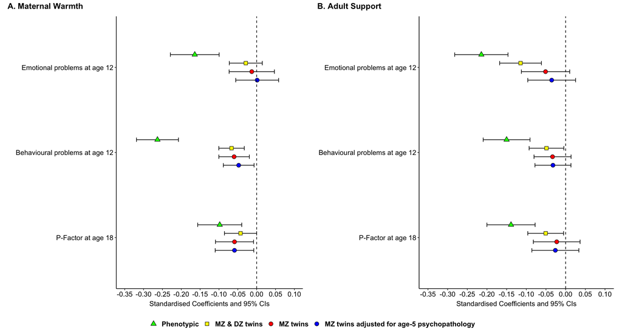

```r
# plot - maternal warmth
mw_plot<- ggplot(maternal_warmth, aes(x=outcome,y=est,fill=type))+
   geom_errorbar(aes(ymin=lowci, ymax=highci), position = position_dodge(width=0.4), width=0.2) +
   geom_point(aes(fill = factor(type), shape = factor(type)), size=3, position=position_dodge2(width=0.4)) +
   scale_x_discrete(name = "") +
   scale_y_continuous(name=expression("Standardised Coefficients and 95% CIs"), limits=c(-0.35,0.1),
                      breaks=c(-0.35,-0.3,-0.25,-0.2,-0.15,-0.1,-0.05,0,0.05,0.1))+
   scale_fill_manual(name="", breaks=c("pheno", "mz_dz", "mz", "mz_adj"), values=c("green", "yellow","red", "blue"),
                     labels=c("Phenotypic", "MZ & DZ twins", "MZ twins", "MZ twins adjusted for age-5 psychopathology"))+
   scale_shape_manual(name="", breaks=c("pheno","mz_dz", "mz", "mz_adj"), values=c(24,22,21,21), labels=c("Phenotypic","MZ & DZ twins", "MZ twins", "MZ twins adjusted for age-5 psychopathology"))+
   geom_hline(yintercept = 0.0, linetype = "dashed")+
   coord_flip()+
   theme_bw() + theme(panel.border = element_blank(), panel.grid.major = element_blank(),
                      panel.grid.minor = element_blank(), axis.line = element_line(colour = "black"),
                      axis.text = element_text(size=12, colour="black"),
                      axis.title.y = element_text (size=12),
                      axis.title.x = element_text (size=12, margin = margin(t=5)),
                      axis.line.y = element_line(color="black"),
                      axis.line.x = element_line(color="black"),
                      legend.position=c(0.85, 0.6),
                      legend.text = element_text(face="bold",size=12),
                      plot.margin=unit(c(1,0.5,0.5,0.5),"cm")
   )

# plot - adult support
ai_plot <- ggplot(adult_involvement, aes(x=outcome,y=est,fill=type))+
   geom_errorbar(aes(ymin=lowci, ymax=highci), position = position_dodge(width=0.4), width=0.2) +
   geom_point(aes(fill = factor(type), shape = factor(type)), size=3, position=position_dodge2(width=0.4)) +
   scale_x_discrete(name = " ") +
   scale_y_continuous(name=expression("Standardised Coefficients and 95% CIs"), limits=c(-0.35,0.1),
                      breaks=c(-0.35,-0.3,-0.25,-0.2,-0.15,-0.1,-0.05,0,0.05,0.1))+
   scale_fill_manual(name="", breaks=c("pheno", "mz_dz", "mz", "mz_adj"), values=c("green", "yellow","red", "blue"),
                     labels=c("Phenotypic", "MZ & DZ twins", "MZ twins", "MZ twins adjusted for individual confounds"))+
   scale_shape_manual(name="", breaks=c("pheno","mz_dz", "mz", "mz_adj"), values=c(24,22,21,21), labels=c("Phenotypic","MZ & DZ twins", "MZ twins", "MZ twins adjusted for individual confounds"))+
   geom_hline(yintercept = 0.0, linetype = "dashed")+
   coord_flip()+
   theme_bw() + theme(panel.border = element_blank(), panel.grid.major = element_blank(),
                      panel.grid.minor = element_blank(), axis.line = element_line(colour = "black"),
                      axis.text = element_text(size=12, colour="black"),
                      axis.title.y = element_text (size=12),
                      axis.title.x = element_text (size=12, margin = margin(t=5)),
                      axis.line.y = element_line(color="black"),
                      axis.line.x = element_line(color="black"),
                      legend.position=c(0.85, 0.6),
                      legend.text = element_text(face="bold",size=12),
                      plot.margin=unit(c(1,0.5,0.5,0),"cm"))

# combine the plots
library(ggpubr)
plot <- ggarrange(mw_plot, ai_plot,  nrow=1, common.legend = TRUE, legend="bottom", labels = c("A. Maternal Warmth", "B. Adult Support"), hjust=c(-0.1,-0.1))
plot
```

## 2.4 Supplementary tables and figures

Testing whether there is an interaction effect of childhood adversity on association between protective factors and mental health.

```r
# Create new copy of data
erisk_posthoc <- subset(erisk)
# Standardise outcomes
erisk_posthoc$totemoe12sd <- scale(erisk_posthoc$totemoe12)
erisk_posthoc$totemoy12sd <- scale(erisk_posthoc$totemoy12)
erisk_posthoc$behave12sd <- scale(erisk_posthoc$behave12)
erisk_posthoc$behavy12sd <- scale(erisk_posthoc$behavy12)
erisk_posthoc$PH_Esd <- scale(erisk_posthoc$PH_E)
erisk_posthoc$PH_Ysd <- scale(erisk_posthoc$PH_Y)
# Standardise exposures
erisk_posthoc$matwarmthesd <- scale(erisk_posthoc$matwarmthe)
erisk_posthoc$matwarmthysd <- scale(erisk_posthoc$matwarmthy)
erisk_posthoc$adultec12sd <- scale(erisk_posthoc$adultec12)
erisk_posthoc$adultyc12sd <- scale(erisk_posthoc$adultyc12)
## Emotional Problems
# Maternal warmth
test <- subset(erisk_posthoc, !is.na(acese512) & !is.na(totemoe12) & !is.na(matwarmthe))
m1 <- lm(totemoe12sd~aces1plus*matwarmthesd + aces1plus + matwarmthesd, data=test)
tbl_regression(m1)

# Adult support
test <- subset(erisk_posthoc, !is.na(acese512) & !is.na(totemoe12) & !is.na(adultec12))
m2 <- lm(totemoe12sd~aces1plus*adultec12sd + aces1plus + adultec12sd, data=test)
tbl_regression(m2)

## Behavioural Problems
# Maternal warmth
test <- subset(erisk_posthoc, !is.na(acese512) & !is.na(behave12) & !is.na(matwarmthe))
m3 <- lm(behave12sd~aces1plus*matwarmthesd + aces1plus + matwarmthesd, data=test)
tbl_regression(m3)

# Adult support
test <- subset(erisk_posthoc, !is.na(acese512) & !is.na(behave12) & !is.na(adultec12))
m4 <- lm(behave12sd~aces1plus*adultec12sd + aces1plus + adultec12sd, data=test)
tbl_regression(m4)

## P-factor
# Maternal warmth
test <- subset(erisk_posthoc, !is.na(acese512) & !is.na(PH_E) & !is.na(matwarmthe))
m5 <- lm(PH_Esd~aces1plus*matwarmthesd + aces1plus + matwarmthesd, data=test)
tbl_regression(m5)

# Adult support
test <- subset(erisk_posthoc, !is.na(acese512) & !is.na(PH_E) & !is.na(adultec12))
m6 <- lm(PH_Esd~aces1plus*adultec12sd + aces1plus + adultec12sd, data=test)
tbl_regression(m6)
```

### 2.4.2 Table S3. Estimates for interaction effects between sex and protective factors with mental health problems

```r
# Recode sex variable. Originally 1 = M, 2 = F.
erisk_1ace$sex <- erisk_1ace$sampsex
erisk_1ace$sex <- recode(erisk_1ace$sex, `1` = 0, `2` = 1)

# Maternal warmth & emotional problems
test <- subset(erisk_1ace, !is.na(totemoe12sd) & !is.na(matwarmthesd))
geemodel <- geeglm(totemoe12sd~matwarmthesd*sex, data=test, id=familyid, corstr="exchangeable")
tidy(geemodel, conf.int = TRUE, conf.level = 0.95)

# Maternal warmth & behavioural problems
test <- subset(erisk_1ace, !is.na(behave12sd) & !is.na(matwarmthesd))
geemodel <- geeglm(behave12sd~matwarmthesd*sex, data=test, id=familyid, corstr="exchangeable")
tidy(geemodel, conf.int = TRUE, conf.level = 0.95)

# Maternal warmth & p-factor
test <- subset(erisk_1ace, !is.na(PH_Esd) & !is.na(matwarmthesd))
geemodel <- geeglm(PH_Esd~matwarmthesd*sex, data=test, id=familyid, corstr="exchangeable")
tidy(geemodel, conf.int = TRUE, conf.level = 0.95)

# Adult support & emotional problems
test <- subset(erisk_1ace, !is.na(totemoe12sd) & !is.na(adultec12sd))
geemodel <- geeglm(totemoe12sd~adultec12sd*sex, data=test, id=familyid, corstr="exchangeable")
tidy(geemodel, conf.int = TRUE, conf.level = 0.95)

# Adult support & behavioural problems
test <- subset(erisk_1ace,  !is.na(behave12sd) & !is.na(adultec12sd))
geemodel <- geeglm(behave12sd~adultec12sd*sex, data=test, id=familyid, corstr="exchangeable")
tidy(geemodel, conf.int = TRUE, conf.level = 0.95)

# Adult support & p-factor
test <- subset(erisk_1ace, !is.na(PH_Esd) & !is.na(adultec12sd))
geemodel <- geeglm(PH_Esd~adultec12sd*sex, data=test, id=familyid, corstr="exchangeable")
tidy(geemodel, conf.int = TRUE, conf.level = 0.95)
```

### 2.4.3 Table S4. Associations between warm and supportive adult involvement and mental health problems, amongst DZ twins exposed to ACEs

```r
## DZ unadjusted
# Maternal warmth & emotional problems
test <- subset(erisk_1ace, zygosity==2 & !is.na(totemoe12sd) & !is.na(matwarm_mean))
geemodel <- geeglm(scale(totemoe12sd) ~ scale(matwarm_mean) + scale(matwarm_diff1), data=test,
                   id=familyid, corstr="exchangeable")
mw_emo <- tidy(geemodel, conf.int = TRUE, conf.level = 0.95) [c(3),c(2,6,7)]; mw_emo <- as.data.frame(mw_emo)
# Maternal warmth & behavioural problems
test <- subset(erisk_1ace, zygosity==2 & !is.na(behave12sd) & !is.na(matwarm_mean))
geemodel <- geeglm(scale(behave12sd) ~ scale(matwarm_mean) + scale(matwarm_diff1), data=test,
                   id=familyid, corstr="exchangeable")
mw_beh <- tidy(geemodel, conf.int = TRUE, conf.level = 0.95) [c(3),c(2,6,7)]; mw_beh <- as.data.frame(mw_beh)
# Maternal warmth & p-factor
test <- subset(erisk_1ace, zygosity==2 & !is.na(PH_E) & !is.na(matwarm_mean))
geemodel <- geeglm(scale(PH_Esd) ~ scale(matwarm_mean) + scale(matwarm_diff1), data=test,
                   id=familyid, corstr="exchangeable")
mw_p <- tidy(geemodel, conf.int = TRUE, conf.level = 0.95) [c(3),c(2,6,7)]; mw_p <- as.data.frame(mw_p)
# Adult support & emotional problems
test <- subset(erisk_1ace, zygosity==2 & !is.na(totemoe12sd) & !is.na(adult_mean))
geemodel <- geeglm(scale(totemoe12sd) ~ scale(adult_mean) + scale(adult_diff1), data=test,
                   id=familyid, corstr="exchangeable")
ai_emo <- tidy(geemodel, conf.int = TRUE, conf.level = 0.95) [c(3),c(2,6,7)]; ai_emo <- as.data.frame(ai_emo)
# Adult support & behavioural problems
test <- subset(erisk_1ace, zygosity==2 & !is.na(behave12sd) & !is.na(adult_mean))
geemodel <- geeglm(scale(behave12sd) ~ scale(adult_mean) + scale(adult_diff1), data=test,
                   id=familyid, corstr="exchangeable")
ai_beh <- tidy(geemodel, conf.int = TRUE, conf.level = 0.95) [c(3),c(2,6,7)]; ai_beh <- as.data.frame(ai_beh)
# Adult support & p-factor
test <- subset(erisk_1ace, zygosity==2 & !is.na(PH_Esd) & !is.na(adult_mean))
geemodel <- geeglm(scale(PH_Esd) ~ scale(adult_mean) + scale(adult_diff1), data=test,
                   id=familyid, corstr="exchangeable")
ai_p <- tidy(geemodel, conf.int = TRUE, conf.level = 0.95) [c(3),c(2,6,7)]; ai_p <- as.data.frame(ai_p)

# save results to data frame
rq2unadjusteddz <- rbind(mw_emo, mw_beh, mw_p, ai_emo, ai_beh, ai_p)
rq2unadjusteddz$model <- NA; rq2unadjusteddz$model <- 5
rq2unadjusteddz$pf <- NA; rq2unadjusteddz$pf <- c("MW", "MW", "MW", "AI", "AI", "AI")
rq2unadjusteddz$outcome <- NA; rq2unadjusteddz$outcome <- c("Emotional","Behavioural", "P-Factor")
rq2unadjusteddz <- rq2unadjusteddz [,c(4,5,6,1,2,3)]
model5 <- rq2unadjusteddz
rq2unadjusteddz <-  rq2unadjusteddz %>%
   rename(
      est_5 = estimate,
      lowci_5 = conf.low,
      highci_5 = conf.high
   )
```

### 2.4.4 Figure S2. Histograms of within-twin differences in mental health outcomes and protective factors

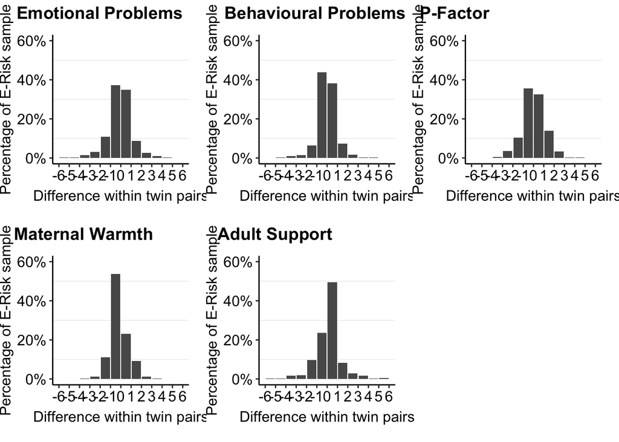

```r
# create difference scores between twins rather than from mean (restrict to rorderp5=0)
histo <- subset(erisk_1ace, rorderp5==0)
histo$emo_difference <- NA; histo$emo_difference <- histo$totemoe12sd - histo$totemoy12sd
histo$beh_difference <- NA; histo$beh_difference <- histo$behave12sd - histo$behavy12sd
histo$p_difference <- NA; histo$p_difference <- histo$PH_Esd - histo$PH_Ysd

histo$mw_difference <- NA; histo$mw_difference <- histo$matwarmthesd - histo$matwarmthysd
histo$as_difference <- NA; histo$as_difference <- histo$adultec12sd - histo$adultyc12sd

# Differences from eldest to youngest twin
ep <- ggplot(data = subset(histo, !is.na(emo_difference)), aes(x=emo_difference)) +
   geom_bar(aes(y = (..count..)/sum(..count..))) +
   scale_x_binned(limits = c(-6,6)) +
   scale_y_continuous(labels = scales::percent_format(accuracy = 1L), limits= c(0,0.6)) +
   labs(x = "Difference within twin pairs", y = "Percentage of E-Risk sample") +
   theme_bw() + theme(panel.border = element_blank(), panel.grid.major = element_blank(),
                      axis.line = element_line(colour = "black"),
                      axis.text = element_text(size=12, colour="black"),
                      axis.title.y = element_text (size=12),
                      axis.title.x = element_text (size=12, margin = margin(t=5)),
                      axis.line.y = element_line(color="black"),
                      axis.line.x = element_line(color="black"),
                      plot.margin=unit(c(1,0.5,0.5,0),"cm"))

bp <- ggplot(data = subset(histo, !is.na(beh_difference)), aes(x=beh_difference)) +
   geom_bar(aes(y = (..count..)/sum(..count..))) +
   scale_x_binned(limits = c(-6,6)) +
   scale_y_continuous(labels = scales::percent_format(accuracy = 1L), limits= c(0,0.6)) +
   labs(x = "Difference within twin pairs", y = "Percentage of E-Risk sample") +
   theme_bw() + theme(panel.border = element_blank(), panel.grid.major = element_blank(),
                      axis.line = element_line(colour = "black"),
                      axis.text = element_text(size=12, colour="black"),
                      axis.title.y = element_text (size=12),
                      axis.title.x = element_text (size=12, margin = margin(t=5)),
                      axis.line.y = element_line(color="black"),
                      axis.line.x = element_line(color="black"),
                      plot.margin=unit(c(1,0.5,0.5,0),"cm"))

pf <- ggplot(data = subset(histo, !is.na(p_difference)), aes(x=p_difference)) +
   geom_bar(aes(y = (..count..)/sum(..count..))) +
   scale_x_binned(limits = c(-6,6)) +
   scale_y_continuous(labels = scales::percent_format(accuracy = 1L), limits= c(0,0.6))  +
   labs(x = "Difference within twin pairs", y = "Percentage of E-Risk sample") + theme_bw(
   ) + theme(panel.border = element_blank(), panel.grid.major = element_blank(),
             axis.line = element_line(colour = "black"),
             axis.text = element_text(size=12, colour="black"),
             axis.title.y = element_text (size=12),
             axis.title.x = element_text (size=12, margin = margin(t=5)),
             axis.line.y = element_line(color="black"),
             axis.line.x = element_line(color="black"),
             plot.margin=unit(c(1,0.5,0.5,0),"cm"))

mw <- ggplot(data = subset(histo, !is.na(mw_difference)), aes(x=mw_difference)) + geom_bar(aes(y = (..count..)/sum(..count..))) +
   scale_x_binned(limits = c(-6,6)) +
   scale_y_continuous(labels = scales::percent_format(accuracy = 1L), limits= c(0,0.6))  +
   labs(x = "Difference within twin pairs", y = "Percentage of E-Risk sample") + theme_bw(
   )+ theme(panel.border = element_blank(), panel.grid.major = element_blank(),
            axis.line = element_line(colour = "black"),
            axis.text = element_text(size=12, colour="black"),
            axis.title.y = element_text (size=12),
            axis.title.x = element_text (size=12, margin = margin(t=5)),
            axis.line.y = element_line(color="black"),
            axis.line.x = element_line(color="black"),
            plot.margin=unit(c(1,0.5,0.5,0),"cm"))

as <- ggplot(data = subset(histo, !is.na(as_difference)), aes(x=as_difference)) +
   geom_bar(aes(y = (..count..)/sum(..count..))) +
   scale_x_binned(limits = c(-6,6)) +
   scale_y_continuous(labels = scales::percent_format(accuracy = 1L), limits= c(0,0.6)) +
   labs(x = "Difference within twin pairs", y = "Percentage of E-Risk sample") +
   theme_bw() + theme(panel.border = element_blank(), panel.grid.major = element_blank(),
                      axis.line = element_line(colour = "black"),
                      axis.text = element_text(size=12, colour="black"),
                      axis.title.y = element_text (size=12),
                      axis.title.x = element_text (size=12, margin = margin(t=5)),
                      axis.line.y = element_line(color="black"),
                      axis.line.x = element_line(color="black"),
                      plot.margin=unit(c(1,0.5,0.5,0),"cm"))

plot <- ggarrange(ep, bp, pf, mw, as, ncol=3, nrow=2, hjust=c(-0.1,-0.1),
                  labels = c("Emotional Problems", "Behavioural Problems", "P-Factor", "Maternal Warmth", "Adult Support"))
plot
```